# **Rosmman slaes prediction**

## By: *FedaaElderdesawe*

### “January 14, 2016”

# **Abstract**

- The objective of this project is to forecast sales using multiple predictors . “Rossmann operates over 3,000 drug stores in 7 European countries. Currently, Rossmann store managers are tasked with predicting their daily sales for up to six weeks in advance. Store sales are influenced by many factors, including promotions, competition, school and state holidays, seasonality, and locality. With thousands of individual managers predicting sales based on their unique circumstances, the accuracy of results can be quite varied” By helping Rossmann create a robust prediction model, you will help store managers stay focused on what’s most important to them: their customers and their teams Prior building our model, the data has been explored; by Exploring relationships between input variables facilitates two things: identifying whether variables need to be dropped due to high correlation, and feature engineering

The best predicted model to forecast sales for next six weeks is the one which estimate the sales at least residuals error ******************************************************

## **Data visulaization**

- Trying to understand the data by plotting histogram for the sales time series The train data for Rossman store has 1115 for each day during the interval between January 2013 till the end of July from 2015

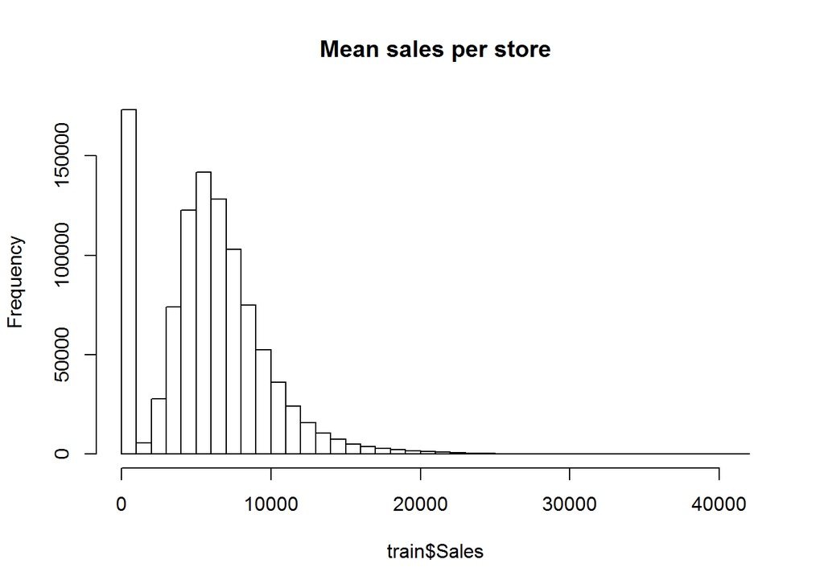

```r
train <- read.csv("C:/Users/fedaaelderdesawe/Desktop/train.csv")
test  <- read.csv("C:/Users/fedaaelderdesawe/Desktop/test.csv")
stores <- read.csv("C:/Users/fedaaelderdesawe/Desktop/store.csv")
hist(train$Sales, 50, main = "Mean sales per store" )
```

## **Data Analysis**

1. *Firstly* I took the frequency for the sales to be the number of stores which is 1115 and I construct the time series and draw boxplot between the sales and the cycle for the data which as its weekly sales data 2.from the boxplot we can the variation in data which indication for seasonality and trend

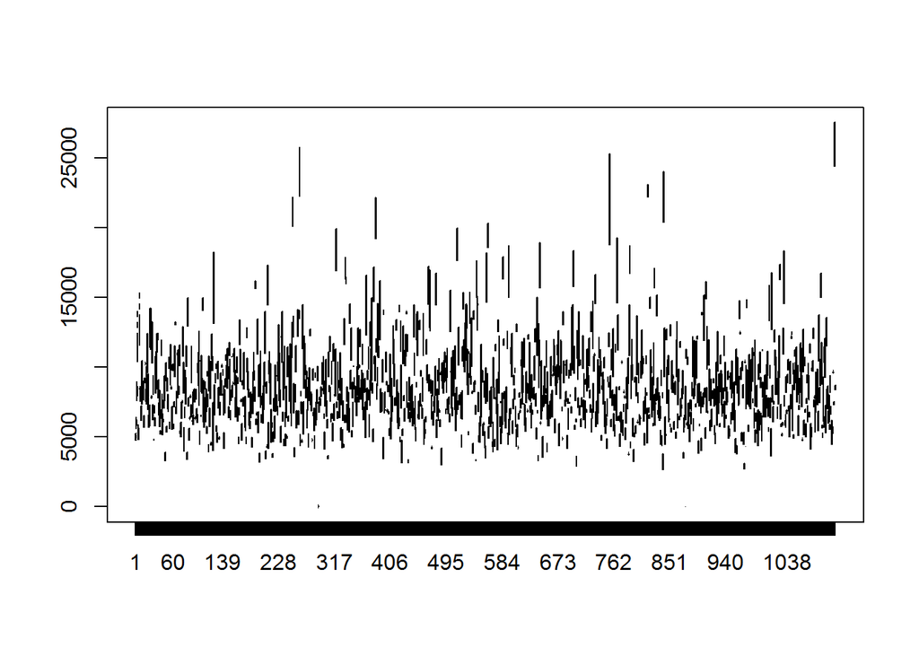

```r
sales.ts <- ts(train$Sales,start=c(2013,1),end=c(2015,7),frequency=1115)
boxplot(sales.ts~cycle(sales.ts))
```

*Secondly* *Building the time series* 1. Then I aggeraate the sales using the list of dates to make time series accorrding to date not depending on each store 2.I assume that the company need to forecast all sales in each store not to forecast the sales for each store

[figure not shown]

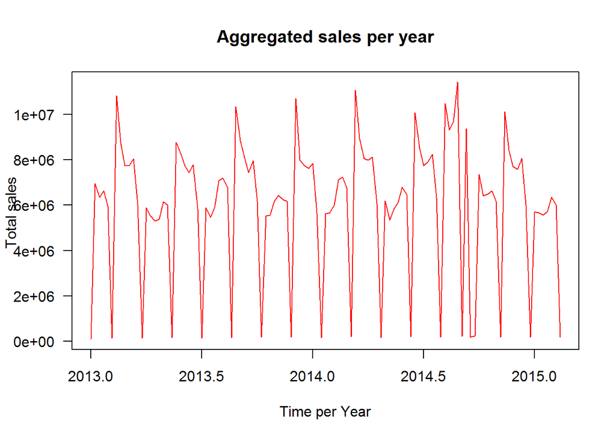

### Decompostion time series

I make decompostion for the aggregate time series to detect the trend and seasonality

1.From the decomposition we can see number of seasons in each cycle and the trend is not stable some times increase and other time decrease ccording to seasonlity. 2.From the Correlogram for sales time series we can see some significant values at repeated periodic different lags which an indicator for seasonality

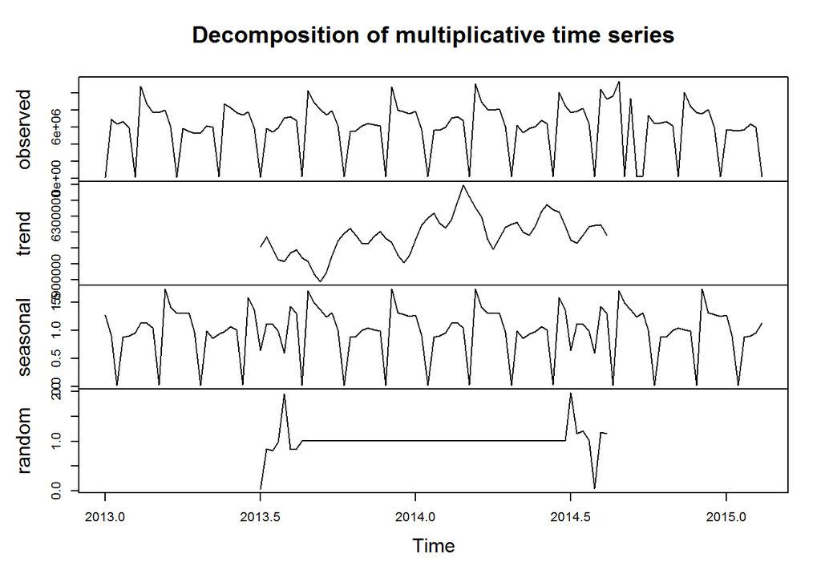

```r
#Decompositions
decompose.agg <- decompose(agg.ts,type = "mult")
plot(decompose.agg)
```

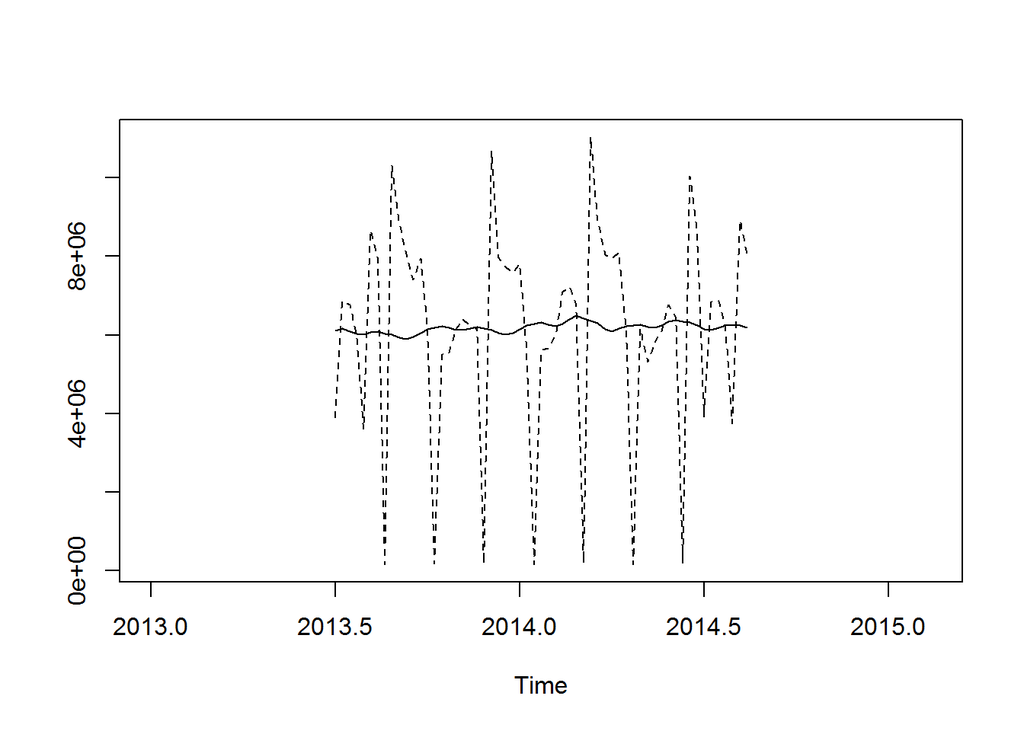

```r
seasonal <- decompose.agg$seasonal
trend <- decompose.agg$trend
random <- decompose.agg$random
ts.plot(cbind(trend, trend * seasonal), lty = 1:2)
```

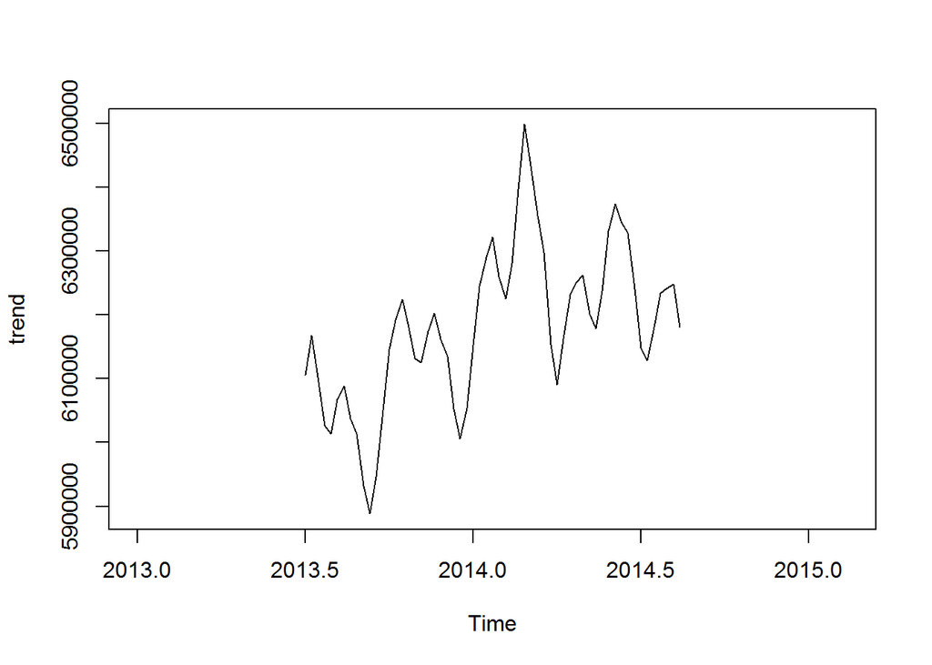

```r
plot.ts(trend)
```

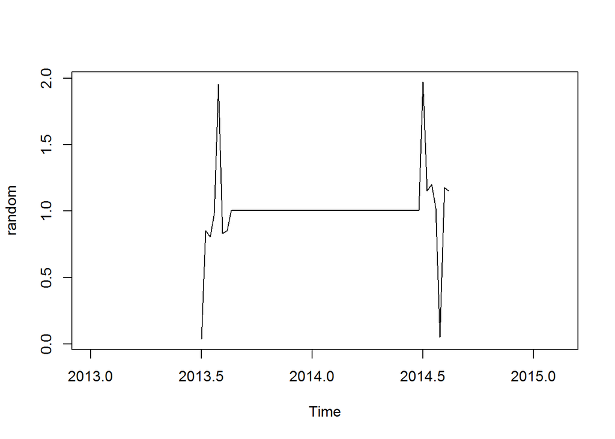

```r
plot.ts(random)
```

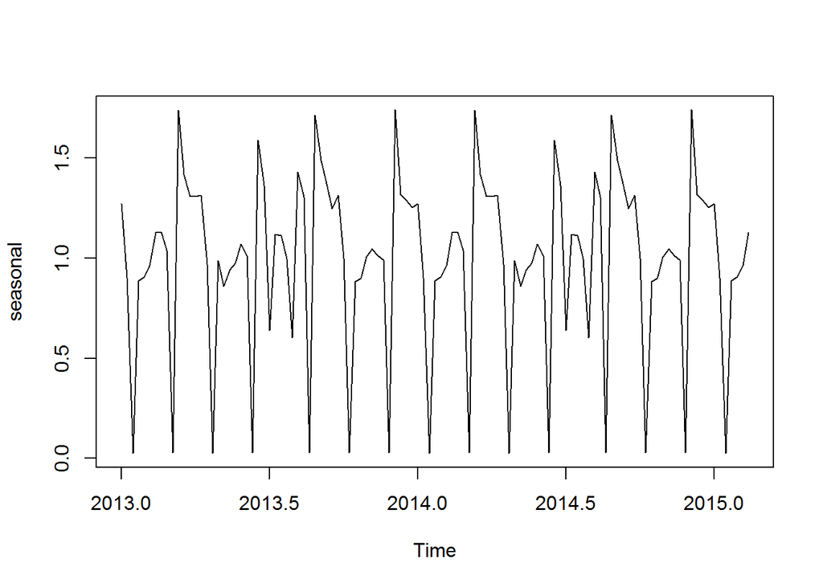

```r
plot.ts(seasonal)
```

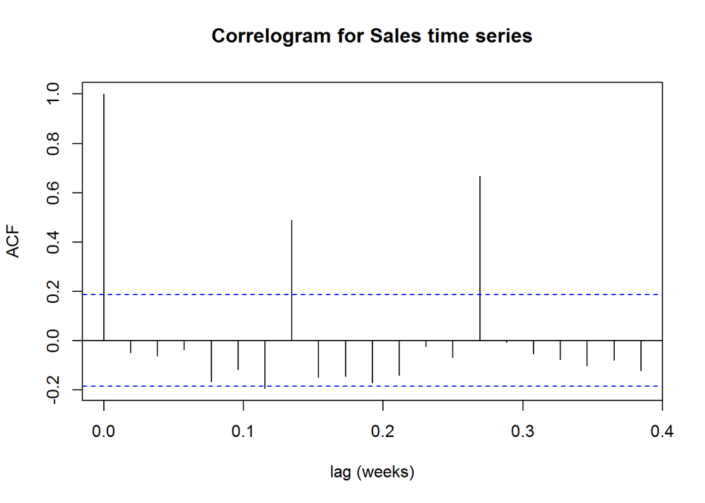

```r
acf(agg.ts, xlab = 'lag (weeks)', main="Correlogram for Sales time series")
```

### Holtwinters method

```r
#Holtwinters model
agg.hw <- HoltWinters(agg.ts,  seas = "mult")
agg.hw ; agg.hw$coef ;agg.hw$SSE
```

```
## Holt-Winters exponential smoothing with trend and multiplicative seasonal component.
##
## Call:
## HoltWinters(x = agg.ts, seasonal = "mult")
##
## Smoothing parameters:
##  alpha: 0
##  beta : 0
##  gamma: 0
##
## Coefficients:
##             [,1]
## a   6.368292e+06
## b   5.797307e+03
## s1  1.148572e+00
## s2  1.058027e+00
## s3  3.081255e-02
## s4  1.766989e+00
## s5  1.440223e+00
## s6  1.328810e+00
## s7  1.328992e+00
## s8  1.336013e+00
## s9  9.864263e-01
## s10 2.675439e-02
## s11 1.003309e+00
## s12 8.730080e-01
## s13 9.570391e-01
## s14 9.914841e-01
## s15 1.086518e+00
## s16 1.027706e+00
## s17 3.086210e-02
## s18 1.615058e+00
## s19 1.385981e+00
## s20 2.372725e-02
## s21 9.666690e-01
## s22 9.072226e-01
## s23 9.945931e-01
## s24 1.192093e+00
## s25 1.204015e+00
## s26 1.129755e+00
```

[output cut: 11 more lines]

```
## s38 1.063293e+00
## s39 1.027528e+00
## s40 1.007533e+00
## s41 2.871293e-02
## s42 1.769351e+00
## s43 1.338459e+00
## s44 1.310410e+00
## s45 1.275274e+00
## s46 1.292579e+00
## s47 9.156657e-01
## s48 2.564266e-02
## s49 9.008551e-01
## s50 9.188321e-01
## s51 9.788846e-01
## s52 1.147880e+00
```

```
##            a            b           s1           s2           s3
## 6.368292e+06 5.797307e+03 1.148572e+00 1.058027e+00 3.081255e-02
##           s4           s5           s6           s7           s8
## 1.766989e+00 1.440223e+00 1.328810e+00 1.328992e+00 1.336013e+00
##           s9          s10          s11          s12          s13
## 9.864263e-01 2.675439e-02 1.003309e+00 8.730080e-01 9.570391e-01
##          s14          s15          s16          s17          s18
## 9.914841e-01 1.086518e+00 1.027706e+00 3.086210e-02 1.615058e+00
##          s19          s20          s21          s22          s23
## 1.385981e+00 2.372725e-02 9.666690e-01 9.072226e-01 9.945931e-01
##          s24          s25          s26          s27          s28
## 1.192093e+00 1.204015e+00 1.129755e+00 2.881837e-02 1.742641e+00
##          s29          s30          s31          s32          s33
## 1.511626e+00 1.394169e+00 1.267350e+00 1.335773e+00 1.016594e+00
##          s34          s35          s36          s37          s38
## 2.826593e-02 8.989822e-01 9.128301e-01 1.021391e+00 1.063293e+00
##          s39          s40          s41          s42          s43
## 1.027528e+00 1.007533e+00 2.871293e-02 1.769351e+00 1.338459e+00
##          s44          s45          s46          s47          s48
## 1.310410e+00 1.275274e+00 1.292579e+00 9.156657e-01 2.564266e-02
##          s49          s50          s51          s52
## 9.008551e-01 9.188321e-01 9.788846e-01 1.147880e+00
```

```
## [1] 7.605065e+14
```

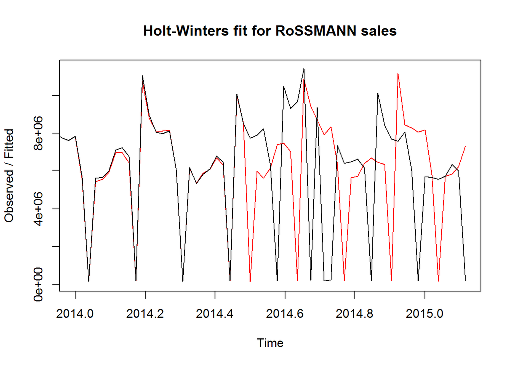

```r
plot (agg.hw,main="Holt-Winters fit for RoSSMANN sales" )
```

```r
#Predictions
agg.predict <- predict(agg.hw, n.ahead = 1 * 52)
agg.predict
```

```
## Time Series:
## Start = c(2015, 8)
## End = c(2016, 7)
## Frequency = 52
##              fit
##  [1,]  7321102.3
##  [2,]  6750089.5
##  [3,]   196759.2
##  [4,] 11293677.6
##  [5,]  9213505.7
##  [6,]  8508470.9
##  [7,]  8517341.8
##  [8,]  8570081.2
##  [9,]  6333318.4
## [10,]   171930.8
```

[output cut: 42 more lines]

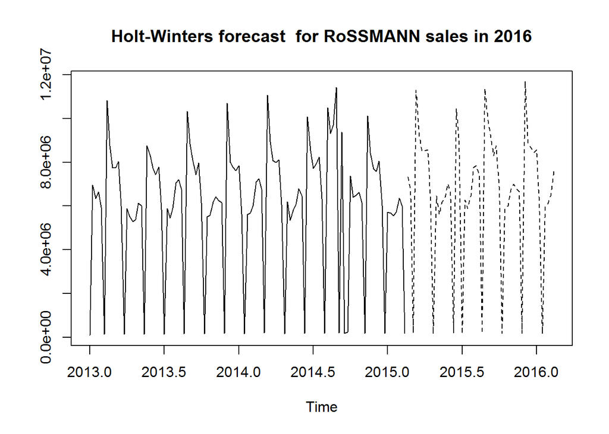

```r
 ts.plot(agg.ts, agg.predict,main="Holt-Winters forecast  for RoSSMANN sales in 2016", lty = 1:2)
```

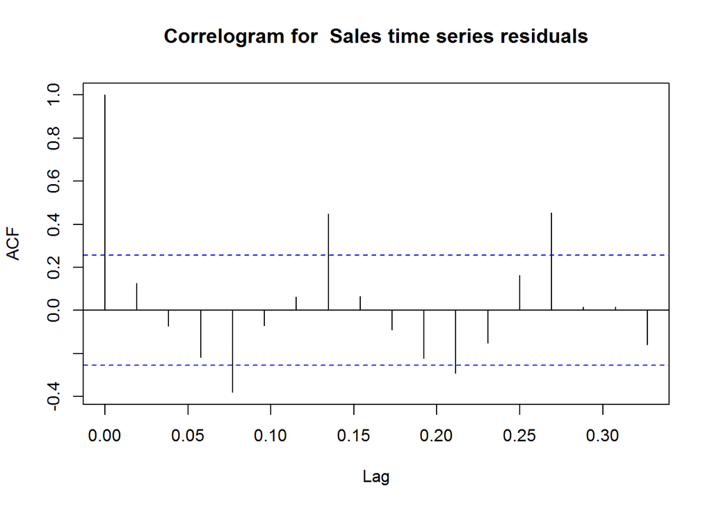

```r
 acf(resid(agg.hw),main="Correlogram for  Sales time series residuals")
```

### Logarithm sales time series

```r
 logagg.ts <- ts(log(aggregatesales[,2]),start=c(2013,1,1),end=c(2015,7,31),frequency=52)
 logg.hw <- HoltWinters(logagg.ts,  seas = "mult")
 loggg.predict <- exp(predict( logg.hw, n.ahead = 1 * 52))
```

## Linear model

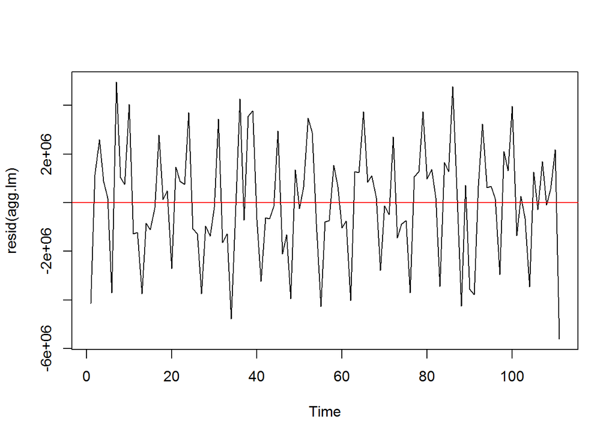

```r
Seas <- cycle(agg.ts)
 Time <-  1:length(agg.ts)
agg.lm <- lm(agg.ts ~  Time + I(Time^2)+ factor(Seas))
plot( Time , resid(agg.lm), type = "l")
abline(0, 0, col = "red")
```

```r
summary(agg.lm)
```

```
##
## Call:
## lm(formula = agg.ts ~ Time + I(Time^2) + factor(Seas))
##
## Residuals:
##      Min       1Q   Median       3Q      Max
## -5611100 -1252399   146627  1277222  4955409
##
## Coefficients:
##                  Estimate Std. Error t value Pr(>|t|)
## (Intercept)     4211197.2  2009713.3   2.095   0.0406 *
## Time              26268.9    42933.5   0.612   0.5431
## I(Time^2)          -228.5      372.1  -0.614   0.5417
## factor(Seas)2   1533830.7  2644813.3   0.580   0.5642
## factor(Seas)3   -531772.9  2644874.6  -0.201   0.8414
## factor(Seas)4   1439645.4  2644975.5   0.544   0.5884
## factor(Seas)5   1436588.0  2645115.7   0.543   0.5892
## factor(Seas)6   -501465.1  2645295.6  -0.190   0.8503
## factor(Seas)7   1487555.4  2645515.9   0.562   0.5761
## factor(Seas)8   3311068.7  2973355.3   1.114   0.2701
## factor(Seas)9   2566707.4  2974041.8   0.863   0.3917
## factor(Seas)10  -732958.9  2974781.4  -0.246   0.8063
## factor(Seas)11  4840088.2  2975562.5   1.627   0.1093
## factor(Seas)12  2755474.7  2976374.3   0.926   0.3585
## factor(Seas)13  -630218.3  2977206.4  -0.212   0.8331
## factor(Seas)14  2192365.7  2978049.1   0.736   0.4646
## factor(Seas)15  2065676.2  2978893.0   0.693   0.4909
## factor(Seas)16   920200.5  2979729.7   0.309   0.7586
## factor(Seas)17 -1988108.6  2980550.9  -0.667   0.5074
## factor(Seas)18  1395533.7  2981349.2   0.468   0.6415
## factor(Seas)19   898130.5  2982117.6   0.301   0.7644
## factor(Seas)20 -1790483.3  2982849.8  -0.600   0.5507
## factor(Seas)21  2642911.4  2983539.9   0.886   0.3794
## factor(Seas)22  2760583.0  2984182.7   0.925   0.3588
## factor(Seas)23  2307468.6  2984773.5   0.773   0.4427
## factor(Seas)24  -982537.3  2985308.1  -0.329   0.7433
## factor(Seas)25  4127308.2  2985782.9   1.382   0.1723
## factor(Seas)26  2383611.7  2986194.9   0.798   0.4281
## factor(Seas)27  -871327.9  2986541.7  -0.292   0.7715
## factor(Seas)28  2078865.0  2986821.2   0.696   0.4892
```

[output cut: 15 more lines]

```
## factor(Seas)44  1397081.6  2982725.1   0.468   0.6413
## factor(Seas)45 -1464377.7  2982103.2  -0.491   0.6253
## factor(Seas)46  3421659.0  2981474.1   1.148   0.2559
## factor(Seas)47  2533501.6  2980846.4   0.850   0.3989
## factor(Seas)48  -812867.4  2980229.4  -0.273   0.7860
## factor(Seas)49  4400315.2  2979632.7   1.477   0.1452
## factor(Seas)50  3289025.1  2979066.7   1.104   0.2742
## factor(Seas)51  2167245.6  2978542.4   0.728   0.4698
## factor(Seas)52  -818390.0  2978071.1  -0.275   0.7845
## ---
## Signif. codes:  0 '***' 0.001 '**' 0.01 '*' 0.05 '.' 0.1 ' ' 1
##
## Residual standard error: 3239000 on 57 degrees of freedom
## Multiple R-squared:  0.3986, Adjusted R-squared:  -0.1605
## F-statistic: 0.7129 on 53 and 57 DF,  p-value: 0.8924
```

```r
coef(agg.lm)
```

```
##    (Intercept)           Time      I(Time^2)  factor(Seas)2  factor(Seas)3
##   4211197.2313     26268.8793      -228.4792   1533830.7267   -531772.9216
##  factor(Seas)4  factor(Seas)5  factor(Seas)6  factor(Seas)7  factor(Seas)8
##   1439645.3884   1436587.9902   -501465.1163   1487555.4022   3311068.7361
##  factor(Seas)9 factor(Seas)10 factor(Seas)11 factor(Seas)12 factor(Seas)13
##   2566707.4205   -732958.9368   4840088.1643   2755474.7237   -630218.2584
## factor(Seas)14 factor(Seas)15 factor(Seas)16 factor(Seas)17 factor(Seas)18
##   2192365.7178   2065676.1523    920200.5452  -1988108.6035   1395533.7062
## factor(Seas)19 factor(Seas)20 factor(Seas)21 factor(Seas)22 factor(Seas)23
##    898130.4742  -1790483.2994   2642911.3854   2760583.0285   2307468.6300
## factor(Seas)24 factor(Seas)25 factor(Seas)26 factor(Seas)27 factor(Seas)28
##   -982537.3101   4127308.2081   2383611.6847   -871327.8804   2078865.0130
## factor(Seas)29 factor(Seas)30 factor(Seas)31 factor(Seas)32 factor(Seas)33
##   2038945.8647   1312553.1747  -1181941.0568   4031045.1700   3232349.8552
## factor(Seas)34 factor(Seas)35 factor(Seas)36 factor(Seas)37 factor(Seas)38
##    112778.4987   6066843.1006   -279379.3391   3932751.6795   -998855.8435
## factor(Seas)39 factor(Seas)40 factor(Seas)41 factor(Seas)42 factor(Seas)43
##   -694076.9081   1966297.9856  -1501614.1622   1220044.6482   1311273.9171
## factor(Seas)44 factor(Seas)45 factor(Seas)46 factor(Seas)47 factor(Seas)48
##   1397081.6443  -1464377.6701   3421658.9738   2533501.5761   -812867.3632
## factor(Seas)49 factor(Seas)50 factor(Seas)51 factor(Seas)52
##   4400315.1559   3289025.1333   2167245.5691   -818390.0368
```

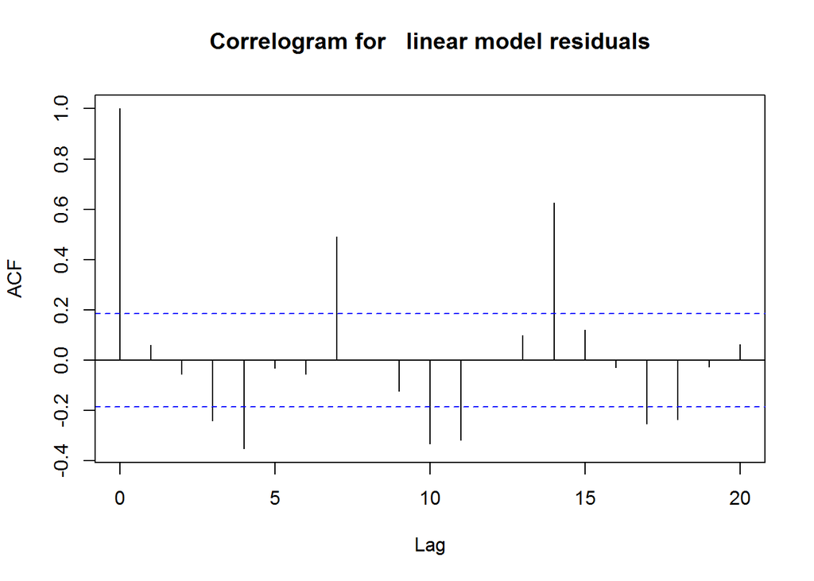

```r
 acf(resid(agg.lm),main="Correlogram for   linear model residuals")
```

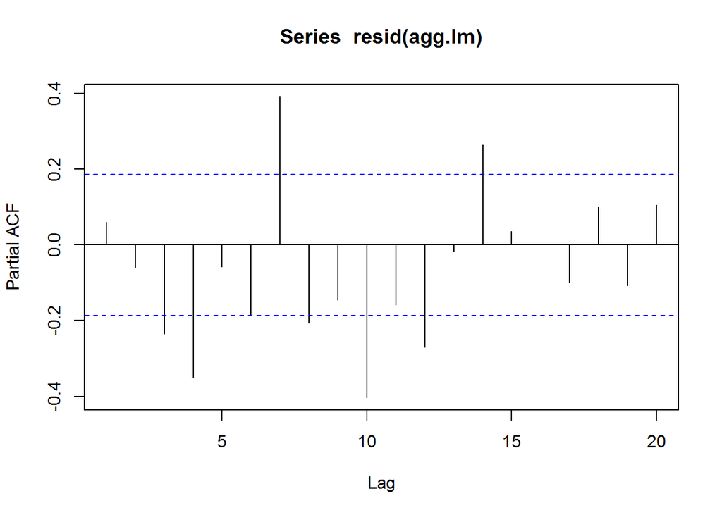

```r
 pacf(resid(agg.lm))
```

###Generalised linear model

I used Generalised linear model to get real estimate of linear model parameters and standard error

```r
 library(nlme)
agg.gls <- gls(agg.ts ~ Time , cor = corAR1(0.07))
 summary(agg.gls)
```

```
## Generalized least squares fit by REML
##   Model: agg.ts ~ Time
##   Data: NULL
##        AIC      BIC    logLik
##   3586.342 3597.107 -1789.171
##
## Correlation Structure: AR(1)
##  Formula: ~1
##  Parameter estimate(s):
##         Phi
## -0.03317275
##
## Coefficients:
##               Value Std.Error   t-value p-value
## (Intercept) 6036984  558556.3 10.808192  0.0000
## Time            -17    8658.5 -0.002015  0.9984
##
##  Correlation:
##      (Intr)
## Time -0.868
##
## Standardized residuals:
##        Min         Q1        Med         Q3        Max
## -1.9674895 -0.1356004  0.1042812  0.6072320  1.7829178
##
## Residual standard error: 3018939
## Degrees of freedom: 111 total; 109 residual
```

## ARIMA model

Trying to fit best fit for the sales time series using arima model

### Results

1.I let R to give me the best order for arima model by assuming that I took the first order of differencing (4,1,5)

2.I let R to Give me the best AIC criteria which is the minimum one : 3488

```r
best.order <- c(0, 1, 0)
best.aic <- Inf
for (i in 0:5) for (j in 0:5) {
  fit.aic <- AIC(arima(resid(agg.lm), order = c(i, 1,j)))
  if (fit.aic < best.aic) {
    best.order <- c(i, 1, j)
    best.arma <- arima(resid(agg.lm), order = best.order)
    best.aic <- fit.aic
  }
}
best.aic
```

```
## [1] 3487.804
```

```r
best.order
```

```
## [1] 4 1 5
```

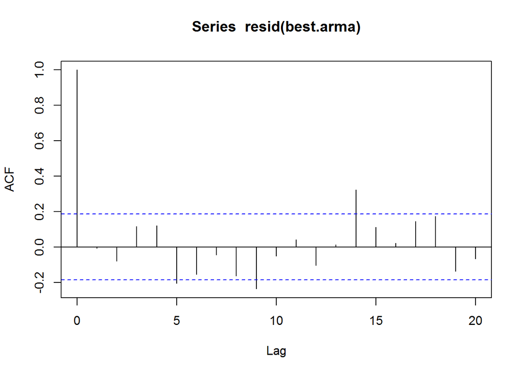

```r
acf(resid(best.arma))
```

```r
#predictions
new.time <- seq(length(agg.ts), length = 6)
new.data <- data.frame(Time = new.time, Imth = rep(7:52,6))
logagg.lm <- lm(log(agg.ts) ~  Time + I(Time^2)+ factor(Seas))

predict.arma <- predict(best.arma, n.ahead = 6)
predict.arma
```

```
## $pred
## Time Series:
## Start = 112
## End = 117
## Frequency = 1
## [1]  1150883.5   560459.3  2034417.4  1483346.4 -1693674.6  -485977.0
##
## $se
## Time Series:
## Start = 112
## End = 117
## Frequency = 1
## [1] 1609497 1610760 1613717 1634747 1669291 1690708
```

#### Build Time series for each store

As we have 1115 stores for the ROSSMANN company so we need to forecast the sales for each store for the next 6 weeks

### *ARIMA linear model for the sales for each store sales*

```r
library(forecast)
n = max(train$Store)

seasonal.naive = function(train, test) {
  test$Date = test$Date - 7*52*2
  #test = subset(train, train$Date %in% dates & train$Store %in% test$Store)
  test = merge(train, test, by=c("Store", "Date"))
  test$Date = test$Date + 7*52*2
  return(test)
}

median.naive = function(train, test) {
    n = max(test$Store)
    for (i in 1:n) { #iterate for stores
        for (j in 1:7) { #itetato for days
            test$Sales[test$Store == i & test$DayOfWeek == j] = median(train$Sales[train$Store==i & train$DayOfWeek == j])
        }
    }
    return(test)
}

tslm.basic <- function(train, test){
  n = max(test$Store)
  for(i in 1:n){
    s <- ts(train$Sales[train$Store==i], frequency=52)
    model <- tslm(s ~ trend + season)
    horizon = length(test$DayOfWeek[test$Store == i])
    fc <- forecast(model, h=horizon)
    test$Sales[test$Store == i] <- as.numeric(fc$mean)
  }
  return(test)
}

arima.basic = function(train, test) {
  n = max(test$Store)
  stores = unique(test$Store)
  for(i in stores){
    s <- ts(train$Sales[train$Store==i], frequency=52)
    model <- auto.arima(s, ic='bic', seasonal = FALSE)
    horizon = length(test$DayOfWeek[test$Store == i])
    fc <- forecast(model, h=horizon)
    test$Sales[test$Store == i] <- as.numeric(fc$mean)
    cat(i, " ")
  }
  return(test)
}

test_id = test$Id

arima = arima.basic(train, test)
```

[output not shown]

```r
arima$Sales[arima$Open == 0] = 0
submission <- data.frame(Id=arima$Id, Sales=arima$Sales)

write.csv(submission, "arima.csv",row.names=F)
```

## **Conclusion**

The Data is hard to visualize every thing as its too big more than 1 million observations .After constructing a real time series I found that it not stationary time series as it contain seasonlity so we need to make it stationarity .I try to build several model using linear regression or ARIMA model to have good model with least errors

Time series model alone is not sufficient for capturing all the variability in data because not all Features are not taken into account and Even after differencing with the suggested d value, data might still non stationary.